# Elektroauto AG - Bundesweite Datenanalyse

05.07.2024  
Datenanalysten: Keanu Kilka, Ryan Oyeneye

# F1 & F3 Verkaufszahlen und Gesamtumsatz

- Es wurden 1104 Autos verkauft
- Der Gesamtumsatz beträgt 98.228.619,38€

# F2 Preisbetrachtung verkaufter Autos

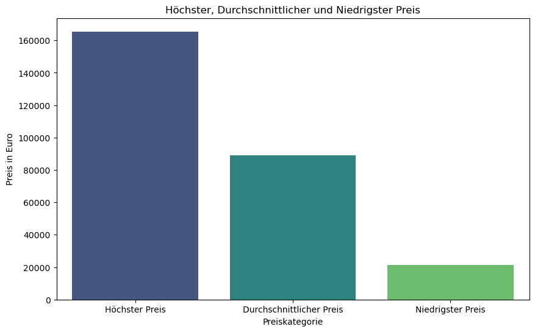

```python
### Balkendiagramm erstellen
plt.figure(figsize=(10, 6))
sns.barplot(x='Preis', y='Wert', data=price_stats, palette='viridis')
plt.title('Höchster, Durchschnittlicher und Niedrigster Preis')
plt.ylabel('Preis in Euro')
plt.xlabel('Preiskategorie')
plt.show()
```

# F4 & F5 Verkaufsmenge und ⌀ Umsatz pro Bundesland

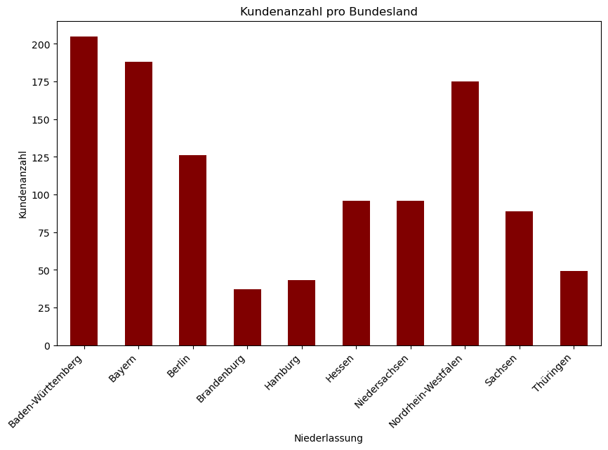

```python
#Balkendiagramm erstellen
#Verwendung von #800000 für die Farbe "Weinrot"
plt.figure(figsize=(10,6))
anzahl_verkauf_pro_land.plot(kind = "bar", color = "#800000")
#Balkendiagramm benennen
plt.title("Kundenanzahl pro Bundesland")
plt.xlabel("Niederlassung")
plt.ylabel("Kundenanzahl")
#Rotieren der Bundeslandbezeichnungen auf der x-Achse (der hinzugefügte Unterstrich unterbindet ungewollte Ausgaben)
_ = plt.xticks(rotation=45, ha='right')
```

```python
#Ermittelung der Spalten wo Preis vorhanden ist
df_mit_preis = df_bkg[df_bkg["Preis"].notna()]
#Ermittlung Durchschnittsumsatz pro Bundesland
durchschnitt_umsatz_pro_land = df_mit_preis.groupby('Niederlassung')['Preis'].mean()
durchschnitt_umsatz_pro_land.sort_values(ascending=False)
```

```
Niederlassung
Baden-Württemberg      90969.560000
Thüringen              90816.994082
Berlin                 89584.984048
Sachsen                89455.080674
Bayern                 89344.313245
Nordrhein-Westfalen    88633.265200
Niedersachsen          87963.312500
Brandenburg            86673.640811
Hessen                 85864.929479
Hamburg                85549.499070
Name: Preis, dtype: float64
```

# F8 Durchschnittsalter - Kunden & Besucher

```python
#Berechnung des Durchschnitssalters unserer Kunden
durchschnittsalter_Kunden = df_mit_preis["Alter"].mean()
durchschnittsalter_Kunden
```

```
50.375
```

```python
#Berechnung des Durchschnitssalters unserer Besucher
#Filtern der Besucher
df_ohne_preis = df_bkg[df_bkg["Preis"].isna()]
#Durchschnittsalter
durchschnittsalter_Besucher = df_ohne_preis["Alter"].mean()
durchschnittsalter_Besucher
```

```
49.88103254769921
```

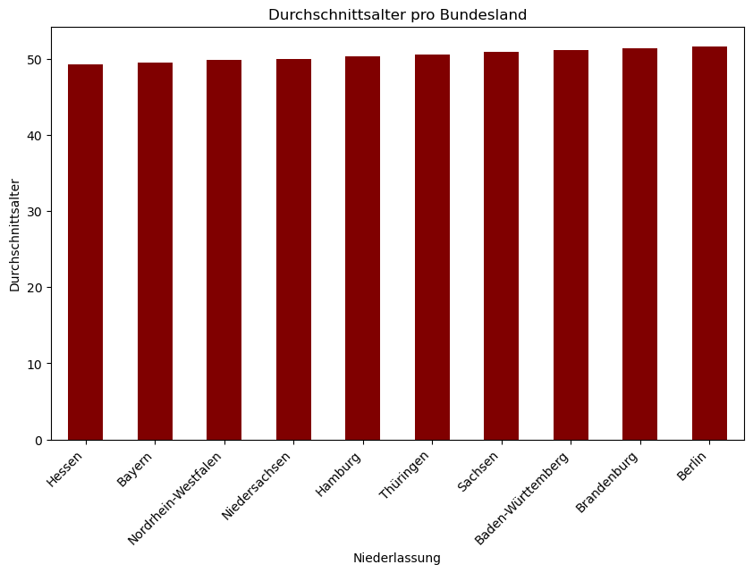

```python
#Balkendiagramm erstellen
plt.figure(figsize=(10,6))
df_durchschnittsalter_pro_bundesland.plot(kind = "bar", color = "#800000")
#Balkendiagramm benennen
plt.title("Durchschnittsalter pro Bundesland")
plt.xlabel("Niederlassung")
plt.ylabel("Durchschnittsalter")
#Rotieren der Bundeslandbezeichnungen auf der x-Achse (der hinzugefügte Unterstrich unterbindet ungewollte Ausgaben)
_ = plt.xticks(rotation=45, ha='right')
```

# F14 sozioökonimische Merkmale - Kaufpreis?

Die Kundenliste einschränken auf die relevanten Merkmale

- Alter
- Einkommen
- Geschlecht
- Zeit

Mittels der Datenpunkte dieser Merkmale bestimmen wir die Regression, um das Außmaß der Beeinflussung abzuwägen

```python
model = sm.OLS(y, X).fit()
model.summary()
```

OLS Regression Results

| Dep. Variable: | Preis | R-squared (uncentered): | 0.988 |
| --- | --- | --- | --- |
| Model: | OLS | Adj. R-squared (uncentered): | 0.988 |
| Method: | Least Squares | F-statistic: | 2.258e+04 |
| Date: | Thu, 27 Jun 2024 | Prob (F-statistic): | 0.00 |
| Time: | 19:41:09 | Log-Likelihood: | -11748. |
| No. Observations: | 1104 | AIC: | 2.350e+04 |
| Df Residuals: | 1100 | BIC: | 2.352e+04 |
| Df Model: | 4 |  |  |
| Covariance Type: | nonrobust |  |  |

|  | coef | std err | t | P>\|t\| | [0.025 | 0.975] |
| --- | --- | --- | --- | --- | --- | --- |
| Einkommen | 1.0261 | 0.036 | 28.535 | 0.000 | 0.956 | 1.097 |
| Alter | 478.1874 | 34.816 | 13.735 | 0.000 | 409.874 | 546.501 |
| Geschlecht | 2126.0678 | 614.882 | 3.458 | 0.001 | 919.593 | 3332.542 |
| Zeit | 69.7922 | 40.464 | 1.725 | 0.085 | -9.602 | 149.187 |

| Omnibus: | 1.263 | Durbin-Watson: | 2.103 |
| --- | --- | --- | --- |
| Prob(Omnibus): | 0.532 | Jarque-Bera (JB): | 1.262 |
| Skew: | 0.014 | Prob(JB): | 0.532 |
| Kurtosis: | 2.837 | Cond. No. | 1.23e+05 |

Notes:  
[1] R² is computed without centering (uncentered) since the model does not contain a constant.  
[2] Standard Errors assume that the covariance matrix of the errors is correctly specified.  
[3] The condition number is large, 1.23e+05. This might indicate that there are  
strong multicollinearity or other numerical problems.

Anhand der Koeffizenten sehen wir wie stark sich der Kaufpreis ändert, wenn wir das jeweilige Merkmal um eine Einheit verändern.

Da der P>|t|-Wert bei der Zeit den Wert 0.05 überschreitet, ist die Zeit ein nicht signifikanter Koeffizient. Daher kann nicht gesagt werden, ob die Zeit einen entscheidenden Einfluss auf den Kaufpreis hat. Dahingegen sind Einkommen, Alter und Geschlecht signifikant.

# F20 Vorschläge an Kundenabteilung bzgl. der Erfassung zusätzlicher Daten

### 1. Sammlung von Daten über den zeitlichen Abstand zum letzten Autokauf.

#### a) Erstellung von Kaufzyklen:

Lebensdauer und Abnutzung des Fahrzeuges verfolgen; Budgetierung und Planung der Anschaffung eines Fahrzeuges nachvollziehen

#### b) Marketingstrategien:

Timing von Angeboten; Maßgeschneiderte Kommunikation wie zum Beispiel Wartungs- und Zubehörangebote für Neukunden und ansprache für neue Autokäufe für alte Kunden

### 2. Sammlung weiterer Demografischer Daten: Bildungsniveau, Familienstand und Berufsstatus.

#### a) Personalisierte Kundenansprache:

Indikatoren nutzen zu einem besseren Angebot wie zum Beispiel bei hohem Bildungsgrade vermehrt technologische Features, bei Familie mit Kindern größere Fahrzeuge mit mehr Sitzen.

#### b) Segmentierung und Marktanalyse:

Identifikation unserer Zielgruppe und gezielte Ansprache auf Basis von Bedürfnisanalysen.

#### c) langfristige Kundenbeziehungen:

Aufbauen auf Basis mehrer Informationen und einer besseren Fähigkeit daraus Rückschlüsse für eine Steigerung der Kundenzufriedenheit zu ziehen.

# Daten zusammenfügen

## 2 Data Frames von Besucher und Kunden zusammenfügen

```python
df_b_k = pd.concat([df_b,df_k], ignore_index = True)
df_b_k
```

|  | Alter | Einkommen | Geschlecht | Zeit | KundeNr | Preis |
| --- | --- | --- | --- | --- | --- | --- |
| 0 | 30 | 39919.095335 | 0.0 | 29.0 | K1814 | NaN |
| 1 | 41 | 53430.673086 | 0.0 | 27.0 | K1544 | NaN |
| 2 | 64 | 73163.216927 | 0.0 | 32.0 | K1945 | NaN |
| 3 | 41 | 36761.482581 | 0.0 | 44.0 | K1825 | NaN |
| 4 | 35 | 42684.331632 | 1.0 | 33.0 | K1144 | NaN |
| ... | ... | ... | ... | ... | ... | ... |
| 1990 | 70 | 69581.000000 | 1.0 | 51.0 | K0467 | 103751.58 |
| 1991 | 38 | 48301.000000 | 1.0 | 33.0 | K0122 | 64230.98 |
| 1992 | 67 | 63547.000000 | 1.0 | 41.0 | K1045 | 103123.57 |
| 1993 | 37 | 32686.000000 | 1.0 | 36.0 | K1096 | 49215.87 |
| 1994 | 55 | 71240.000000 | 1.0 | 49.0 | K0861 | 106132.59 |

1995 rows × 6 columns

## 3 Data Frames von geo zur kombinierten Liste hinzufügen

```python
df_bkg = pd.merge(df_b_k, df_geo, on = "KundeNr")
df_bkg
```

|  | Alter | Einkommen | Geschlecht | Zeit | KundeNr | Preis | Niederlassung |
| --- | --- | --- | --- | --- | --- | --- | --- |
| 0 | 30 | 39919.095335 | 0.0 | 29.0 | K1814 | NaN | Bayern |
| 1 | 41 | 53430.673086 | 0.0 | 27.0 | K1544 | NaN | Baden-Württemberg |
| 2 | 64 | 73163.216927 | 0.0 | 32.0 | K1945 | NaN | Baden-Württemberg |
| 3 | 41 | 36761.482581 | 0.0 | 44.0 | K1825 | NaN | Baden-Württemberg |
| 4 | 35 | 42684.331632 | 1.0 | 33.0 | K1144 | NaN | Nordrhein-Westfalen |
| ... | ... | ... | ... | ... | ... | ... | ... |
| 1990 | 70 | 69581.000000 | 1.0 | 51.0 | K0467 | 103751.58 | Thüringen |
| 1991 | 38 | 48301.000000 | 1.0 | 33.0 | K0122 | 64230.98 | Niedersachsen |
| 1992 | 67 | 63547.000000 | 1.0 | 41.0 | K1045 | 103123.57 | Berlin |
| 1993 | 37 | 32686.000000 | 1.0 | 36.0 | K1096 | 49215.87 | Baden-Württemberg |
| 1994 | 55 | 71240.000000 | 1.0 | 49.0 | K0861 | 106132.59 | Bayern |

1995 rows × 7 columns

# Datenbereinigung

bereinigt wurden

- Einkommen (obere Schranke = 200k€, untere Schranke 10k€)
- Alter (obere Schranke ca. 90 Jahre)
- Geschlecht (fehlende Werte durch Modus ersetzt)

## Hier am Beispiel des Einkommens:

```python
# Berechnung von Q1 (25. Perzentil), Q3 (75. Perzentil) und IQR
Q1 = df_bkg['Einkommen'].quantile(0.25)
Q3 = df_bkg['Einkommen'].quantile(0.75)
IQR = Q3 - Q1

# Berechnung der Ausreißer-Grenzen
untere_grenze = Q1 - 1.6 * IQR #Faktor auf die Ausreißer nach eigenem Ermessen angepasst
obere_grenze = Q3 + 5 * IQR #Faktor auf die Ausreißer nach eigenem Ermessen angepasst

# Identifizierung von Ausreißern
df_bkg['Ausreißer'] = (df_bkg['Einkommen'] < untere_grenze) | (df_bkg['Einkommen'] > obere_grenze)

df_bkg
```

|  | Alter | Einkommen | Geschlecht | Zeit | KundeNr | Preis | Niederlassung | Ausreißer |
| --- | --- | --- | --- | --- | --- | --- | --- | --- |
| 0 | 30 | 39919.095335 | 0.0 | 29.0 | K1814 | NaN | Bayern | False |
| 1 | 41 | 53430.673086 | 0.0 | 27.0 | K1544 | NaN | Baden-Württemberg | False |
| 2 | 64 | 73163.216927 | 0.0 | 32.0 | K1945 | NaN | Baden-Württemberg | False |
| 3 | 41 | 36761.482581 | 0.0 | 44.0 | K1825 | NaN | Baden-Württemberg | False |
| 4 | 35 | 42684.331632 | 1.0 | 33.0 | K1144 | NaN | Nordrhein-Westfalen | False |
| ... | ... | ... | ... | ... | ... | ... | ... | ... |
| 1990 | 70 | 69581.000000 | 1.0 | 51.0 | K0467 | 103751.58 | Thüringen | False |
| 1991 | 38 | 48301.000000 | 1.0 | 33.0 | K0122 | 64230.98 | Niedersachsen | False |
| 1992 | 67 | 63547.000000 | 1.0 | 41.0 | K1045 | 103123.57 | Berlin | False |
| 1993 | 37 | 32686.000000 | 1.0 | 36.0 | K1096 | 49215.87 | Baden-Württemberg | False |
| 1994 | 55 | 71240.000000 | 1.0 | 49.0 | K0861 | 106132.59 | Bayern | False |

1995 rows × 8 columns

# F6 In welchem Bundesland wurde das teuerste Auto verkauft?

Das teuerste Auto wurde in Niedersachsen verkauft

```python
max_preis_index = df_mit_preis["Preis"].idxmax()
bundesland_teuerstes_auto = df_mit_preis.loc[max_preis_index, "Niederlassung"]
bundesland_teuerstes_auto
```

```
'Niedersachsen'
```

# F7 Haben mehr Frauen oder mehr Männer unsere Autos gekauft?

Es haben mehr Männer unsere Autos gekauft

```python
df_preis_vorhanden["Geschlecht"].mode()
```

```
0    1.0
Name: Geschlecht, dtype: float64
```

# F11 Korrelation - Alter, Einkommen, Preis und Zeit?

Die Pearson Korrelation liegt wie folgt zwischen den Variablen Alter, Einkommen, Preis und Zeit:

```python
corr_kundenwerte = df_preis_vorhanden[["Alter", "Einkommen", "Preis", "Zeit"]].corr()
corr_kundenwerte
```

|  | Alter | Einkommen | Preis | Zeit |
| --- | --- | --- | --- | --- |
| Alter | 1.000000 | 0.761572 | 0.780478 | 0.588912 |
| Einkommen | 0.761572 | 1.000000 | 0.896565 | 0.776211 |
| Preis | 0.780478 | 0.896565 | 1.000000 | 0.707778 |
| Zeit | 0.588912 | 0.776211 | 0.707778 | 1.000000 |

# F12 Zeit approximativ normalverteilt? - qq-Plots

Die variable Zeit kann als approximativ normalverteilt betrachtet werden.

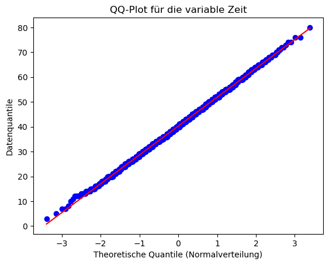

```python
#import matplotloib und scipy
import matplotlib.pyplot as plt
import scipy.stats as stats

#variable Zeit
zeit = df_bkg["Zeit"]

#QQ-Plot erstellen
stats.probplot(zeit, dist="norm", plot=plt)
plt.title("QQ-Plot für die variable Zeit")
plt.xlabel("Theoretische Quantile (Normalverteilung)")
plt.ylabel("Datenquantile")
plt.show()
```

# F9 Durchschnittseinkommen Kunden & Besucher?

- Das Durchschnittseinkommen unserer Kunden beträgt in etwa 58.895,25 €
- Das Durchschnittseinkommen unserer Besucher beträgt in etwa 59.367,94 €

```python
#Berechnung des Durchschnitteinkommens unserer Kunden
df_preis_vorhanden["Einkommen"].mean()
```

```
58895.24686507354
```

```python
#Berechnung des Durchschnitteinkommens unserer Besucher
#Ermittlungen der Zeilen mit NAN in der Preis-Spalte
df_preis_nicht_vorhanden = df_bkg[df_bkg["Preis"].isna()]
#Durchschnittseinkommen der Besucher berechenen
df_preis_nicht_vorhanden["Einkommen"].mean()
```

```
59367.93618779704
```

# F13 Bankkredit für Autokauf?

Man kann davon ausgehen, dass 5 Kunden keinen Kredit aufgenommen haben, um das Auto zu kaufen

```python
#Filterung nach Einkommen-Spalte, wobei in Zeile: Einkommen > Preis
df_kein_kredit = df_preis_vorhanden.loc[df_preis_vorhanden["Einkommen"] > df_preis_vorhanden["Preis"], "Einkommen"]
df_kein_kredit
```

```
1048    50330.0
1298    24264.0
1390    54403.0
1533    30856.0
1587    36296.0
Name: Einkommen, dtype: float64
```

# F15 Prognose Kaufpreis:

Kundenprofil - Einkommen von 30.000 Euro und Alter 32 Jahre alt

```python
 y1 = pd.DataFrame({"Alter" : [32], "Einkommen" : [30000], "Geschlecht" : [1], "Zeit" : [df_preis_vorhanden["Zeit"].mean()]})
y1 = sm.add_constant(y1)
y1
```

|  | Alter | Einkommen | Geschlecht | Zeit |
| --- | --- | --- | --- | --- |
| 0 | 32 | 30000 | 1 | 44.375906 |

```python
Prognose1 = model.predict(y1)
Prognose1
```

[output not shown]

# F15 Prognose Kaufpreis: Kundenprofil - Einkommen von 54.000 Euro + Alter 51 Jahre alt

```python
y2 = pd.DataFrame({"Alter" : [51], "Einkommen" : [54000], "Geschlecht" : [1], "Zeit" : [df_preis_vorhanden["Zeit"].mean()]})
y1 = sm.add_constant(y1)
Prognose2 = model.predict(y2)
Prognose2
```

[output not shown]

# F16 Welche Variable beeinflusst den Kaufpreis am stärksten?

Die Variable, die den Preis beim Kauf des Autos am meisten beeinflusst, ist das Einkommen.

```python
import statsmodels.api as sm
from sklearn.preprocessing import StandardScaler
# Auswahl der unabhängigen Variablen und der abhängigen Variable
X = df_preis_vorhanden[["Einkommen", "Alter", "Geschlecht", "Zeit"]]
y = df_preis_vorhanden["Preis"]


# Standardisieren der unabhängigen Variablen
scaler_X = StandardScaler()
scaler_y = StandardScaler()

X_standardized = scaler_X.fit_transform(X)



# Da y eine pandas Series ist, muss sie in ein 2D-Array umgewandelt werden
y_standardized = scaler_y.fit_transform(y.values.reshape(-1, 1)).flatten()


# Konvertieren der standardisierten Variablen zurück in ein DataFrame und hinzufügen einer Konstante
X_standardized = pd.DataFrame(X_standardized, columns=X.columns)
X_standardized = sm.add_constant(X_standardized)



# Regression schätzen (lineare Regression)
model_standardized = sm.OLS(y_standardized, X_standardized).fit()
```

```python
# Zusammenfassung des Modells anzeigen
model_standardized.summary()
```

OLS Regression Results

| Dep. Variable: | y | R-squared: | 0.829 |
| --- | --- | --- | --- |
| Model: | OLS | Adj. R-squared: | 0.828 |
| Method: | Least Squares | F-statistic: | 1329. |
| Date: | Thu, 27 Jun 2024 | Prob (F-statistic): | 0.00 |
| Time: | 20:07:20 | Log-Likelihood: | -592.62 |
| No. Observations: | 1104 | AIC: | 1195. |
| Df Residuals: | 1099 | BIC: | 1220. |
| Df Model: | 4 |  |  |
| Covariance Type: | nonrobust |  |  |

|  | coef | std err | t | P>\|t\| | [0.025 | 0.975] |
| --- | --- | --- | --- | --- | --- | --- |
| const | -4.857e-16 | 0.012 | -3.89e-14 | 1.000 | -0.024 | 0.024 |
| Einkommen | 0.6921 | 0.025 | 28.005 | 0.000 | 0.644 | 0.741 |
| Alter | 0.2344 | 0.019 | 12.162 | 0.000 | 0.197 | 0.272 |
| Geschlecht | 0.0420 | 0.012 | 3.362 | 0.001 | 0.017 | 0.067 |
| Zeit | 0.0316 | 0.020 | 1.598 | 0.110 | -0.007 | 0.071 |

| Omnibus: | 1.250 | Durbin-Watson: | 2.103 |
| --- | --- | --- | --- |
| Prob(Omnibus): | 0.535 | Jarque-Bera (JB): | 1.252 |
| Skew: | 0.014 | Prob(JB): | 0.535 |
| Kurtosis: | 2.837 | Cond. No. | 3.80 |

Notes:  
[1] Standard Errors assume that the covariance matrix of the errors is correctly specified.

```python
# Extrahieren der Koeffizienten (ohne den Intercept)
coefficients = model_standardized.params[1:]  # Der erste Koeffizient ist der Intercept, den wir ignorieren
variables = X.columns


# Erstellen eines Datenrahmens für die Visualisierung
coef_df = pd.DataFrame({
    'Variable': variables,
    'Koeffizient': coefficients
})
```

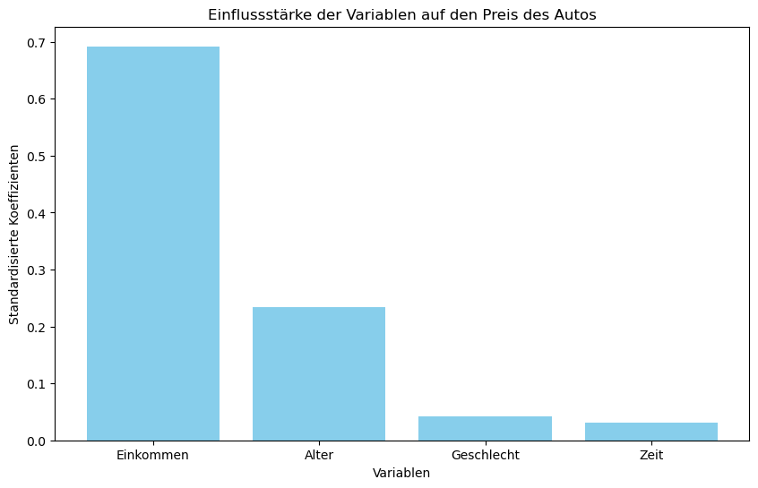

```python
# Balkendiagramm erstellen
plt.figure(figsize=(10, 6))
plt.bar(coef_df['Variable'], coef_df['Koeffizient'], color='skyblue')
plt.xlabel('Variablen')
plt.ylabel('Standardisierte Koeffizienten')
plt.title('Einflussstärke der Variablen auf den Preis des Autos')
```

# F17 Schätzung Regression - Autokauf

```python
#definieren der abhängigen Variable
model_lg.summary()
```

Logit Regression Results

| Dep. Variable: | Kauf | No. Observations: | 1995 |
| --- | --- | --- | --- |
| Model: | Logit | Df Residuals: | 1990 |
| Method: | MLE | Df Model: | 4 |
| Date: | Thu, 27 Jun 2024 | Pseudo R-squ.: | 0.1577 |
| Time: | 20:10:35 | Log-Likelihood: | -1155.1 |
| converged: | True | LL-Null: | -1371.4 |
| Covariance Type: | nonrobust | LLR p-value: | 2.469e-92 |

|  | coef | std err | z | P>\|z\| | [0.025 | 0.975] |
| --- | --- | --- | --- | --- | --- | --- |
| const | -2.4426 | 0.263 | -9.270 | 0.000 | -2.959 | -1.926 |
| Einkommen | -4.213e-05 | 5.43e-06 | -7.761 | 0.000 | -5.28e-05 | -3.15e-05 |
| Alter | 0.0180 | 0.007 | 2.630 | 0.009 | 0.005 | 0.031 |
| Geschlecht | 0.2466 | 0.103 | 2.395 | 0.017 | 0.045 | 0.448 |
| Zeit | 0.1022 | 0.006 | 17.532 | 0.000 | 0.091 | 0.114 |

# F18 Wahrscheinlichkeitsberechnung 1

#### Kundenprofil: 32-jähriger männlicher Kunde mit einem Einkommen von 30.000 Euro, der das Auto 30 Minuten lang getestet hat, eines unserer Modelle kauft?

Auf Basis der Koeffizienten aus der geschätzten Regression zur Wahrscheinlichkeit eines Autokaufs, lässt sich ermitteln, dass die Wahrscheinlichkeit, dass ein 32-Jähriger männlicher Kunde mit einem Einkommen von 30.000 € und einer 30-Minütigen Testdauer Kauft liegt in etwa bei 54,54 %

```python
import math

# Koeffizienten
intercept = -2.4426
coef_Einkommen = -0.00004213
coef_Alter = 0.0180
coef_Geschlecht = 0.2466
coef_Zeit = 0.1022

# Werte der unabhängigen Variablen
x_Einkommen = 30000
x_Alter = 32
x_Geschlecht = 1
x_Zeit = 30

# Berechnung der linearen Kombination
linear_combination = intercept + (coef_Einkommen * x_Einkommen) + (coef_Alter * x_Alter) + (coef_Geschlecht * x_Geschlecht) + (coef_Zeit * x_Zeit)

# Berechnung der Wahrscheinlichkeit
Wahrscheinlichkeit_Kauf = 1 / (1 + math.exp(-linear_combination))*100

f"{Wahrscheinlichkeit_Kauf} %"
```

```
'54.53996134650454 %'
```

# F18 Wahrscheinlichkeitsberechnung 2

#### Kundenprofil: 51-jähriger männlicher Kunde mit einem Einkommen von 54.000 Euro, der das Auto 45 Minuten lang getestet hat, eines unserer Modelle kauft?

Die Wahrscheinlichkeit, dass ein 51-Jähriger männlicher Kunde mit einem Einkommen von 54.000 € und einer 45-Minütigen Testdauer kauft, liegt hingegen mit in etwa 74 % deutlich höher.

```python
# Koeffizienten
intercept = -2.4426
coef_Einkommen = -0.00004213
coef_Alter = 0.0180
coef_Geschlecht = 0.2466
coef_Zeit = 0.1022

# Werte der unabhängigen Variablen
x_Einkommen = 54000
x_Alter = 51
x_Geschlecht = 1
x_Zeit = 45

# Berechnung der linearen Kombination
linear_combination = intercept + (coef_Einkommen * x_Einkommen) + (coef_Alter * x_Alter) + (coef_Geschlecht * x_Geschlecht) + (coef_Zeit * x_Zeit)

# Berechnung der Wahrscheinlichkeit
Wahrscheinlichkeit_Kauf = 1 / (1 + math.exp(-linear_combination)) * 100

f"{Wahrscheinlichkeit_Kauf} %"
```

```
'74.00022019768025 %'
```